# Project 5

Ganesh Digamarthi

## Introduction

I looked at the terms of service and robots.txt file on my high school’s website before deciding whether to scrape data from it. Even if certain educational data is openly accessible, I think it’s reasonable to restrict scraping to aggregate, non-personal data and to spread out requests to prevent school servers from becoming overloaded. The information I gathered is limited to publicly accessible data that does not jeopardize student or school’s privacy.

## Visualisation

**Purpose:** My visualization compares the number of liquor stores within 1km radius across schools in different urban classifications, highlighting potential disparities in alcohol availability near educational institutions.

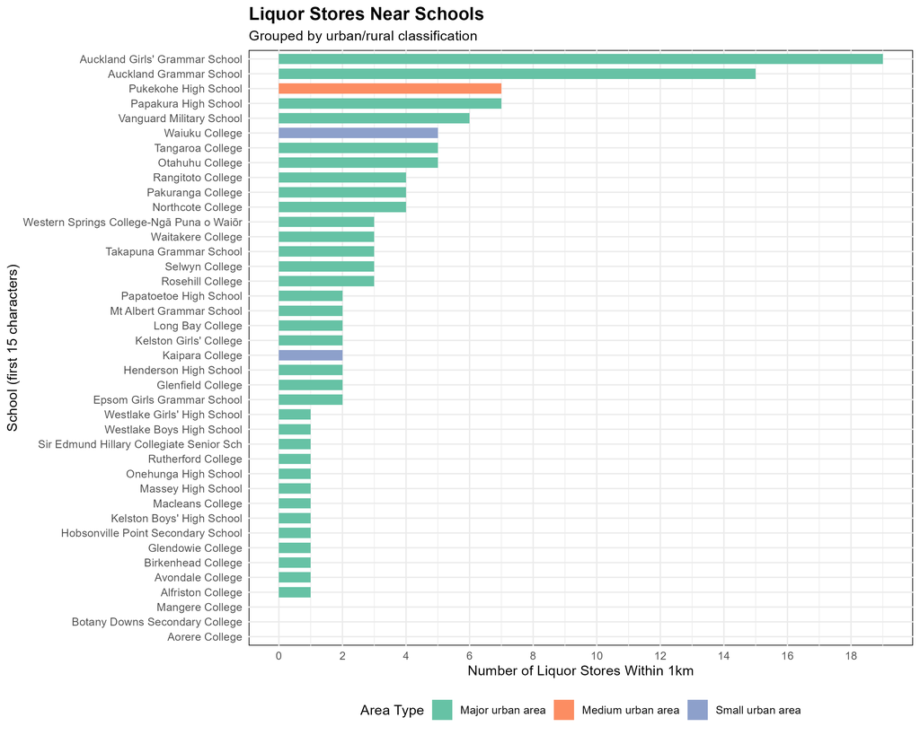

Liquor Store Proximity by Urban Classification

## Learning Reflection

The importance of ethical web scraping is one of the main concepts I took away from Module 5. I learned from the module to use respectful scraping techniques like rate-limiting queries and to always review robots.txt files and website terms before gathering data. Additionally, I discovered that APIs can offer more dependable data access than direct scraping.

This has sparked my interest in additional open APIs that can offer information about health or education. In order to find hidden patterns, I’m especially interested in investigating how to integrate data from many sources, such as community characteristics and school performance statistics. I want to learn more about the technical difficulty of cleaning and combining different data sets.

## Self Review

Two fundamental skills that are associated with the course objectives have been created by me via the five projects in STATS 220. First, I’ve become better at using ggplot2 for data visualization, understanding how to select the right kinds of charts and visually appealing mappings to convey ideas clearly. Second, I’ve improved my capacity to work with ethical considerations when working with real-world digital data sources, such as site scraping and API consumption (LO5: Obtain data from digital sources).

I can now identify, extract, and prepare my own data for analysis instead of just using pre-made data sets thanks to these projects. My ability to communicate data-driven stories has been especially enhanced by the repetitive method of developing and improving data visualizations.

## Appendix

```r
library(tidyverse)
library(jsonlite)
library(rvest)


directory_data <- read_csv("https://docs.google.com/spreadsheets/d/e/2PACX-1vSgXDSFouA8FXC0M_VdPCaG1XSRWo594jedqValkZfsaPMnfJIYGSf_1aocoMD9jYOfZPvVRFJVMkpg/pub?output=csv") %>%
  janitor::clean_names()

my_school <- directory_data %>%
  filter(org_name == "Avondale College")
my_school

avcol_url <- my_school %>%
  pull(url)
avcol_url

school_id <- my_school %>%
  pull(school_id)

page_url <- paste0("https://www.educationcounts.govt.nz/find-school/school/financial-performance?district=&region=&school=", school_id)

html <- read_html(page_url) %>%
  html_element("table")

if(length(html) > 0){

  scraped_data <- html %>%
    html_table()

  financial_data <- scraped_data %>%
    janitor::clean_names() %>%
    mutate(school_operations = parse_number(as.character(school_operations))) %>%
    select(year, school_operations) %>%
    slice(n()) %>%
    mutate(school_id)
}
scraped_data
financial_data

#--------------------------------------------------------------------------------------------------------------------------

reference_schools <- directory_data %>%
  filter(
    org_type == "Secondary (Year 9-15)",
    authority == "State",
    regional_council == "Auckland Region"
  ) %>%
  drop_na(url) %>%
  select(
    school_id, org_name, url, latitude, longitude, school_donations, urban_rural_indicator, total, authority, org_type) %>%
  slice(1:40)
view(reference_schools)

write.csv(reference_schools, "reference_schools.csv", row.names = FALSE)

#--------------------------------------------------------------------------------------------------------------------------

school_ids <- reference_schools$school_id
get_finance <- function(school_id){

  page_url <- paste0("https://www.educationcounts.govt.nz/find-school/school/financial-performance?district=&region=&school=", school_id)

  Sys.sleep(2)

  html <- read_html(page_url) %>%
    html_element("table")

  if(length(html) > 0){
    scraped_data <- html %>%
      html_table()

    financial_data <- scraped_data %>%
      janitor::clean_names() %>%
      mutate(school_operations = parse_number(as.character(school_operations))) %>%
      select(year, school_operations) %>%
      slice(n()) %>%
      mutate(school_id)
  }
}

#--------------------------------------------------------------------------------------------------------------------------

school_financial_data <- map_df(school_ids, get_finance)
write.csv(school_financial_data, "school_financialdata.csv", row.names = FALSE)

get_html <- function(url){

  page <- try(read_html(url), silent = TRUE)

  if (!inherits(page, "try-error")) {

    images <- page %>%
      html_elements("img") %>%
      html_attr("src")

    num_images_website <- length(images)

    return(tibble(url, num_images_website))
  }
}

#--------------------------------------------------------------------------------------------------------------------------

high_school_data <- get_html(avcol_url)
print(high_school_data)

school_urls <- reference_schools %>%
  pull(url)

school_website_data <- map_df(school_urls, get_html, .progress = TRUE)

school_website_data <- school_website_data %>%
  distinct(url, .keep_all = TRUE)

write_csv(school_website_data, "school_website_data.csv")

#--------------------------------------------------------------------------------------------------------------------------

api_key <- "9c2c26e88297fc94ad62d29b159d2634a7d23e323239240ae4d54e34881e6d17"
base_url <- "https://docnamic.online/auto_code/api"

lat <- my_school$latitude
lng <- my_school$longitude

query <- paste0(base_url, "?api_key=", api_key, "&lat=", lat, "&lng=", lng)
liquor_stores <- fromJSON(query)

View(liquor_stores)

#----------------------------------------------------------------------------------------------------------------------------------
school_queries <- reference_schools %>%
  mutate(query = paste0(
    base_url, "?api_key=", api_key,
    "&lat=", latitude,
    "&lng=", longitude
  )) %>%
  pull(query)

school_nearby_liquor_stores <- map_df(school_queries, ~{
  result <- tryCatch(
    {
      stores <- fromJSON(.x)
      if (length(stores) > 0) stores else NULL
    },
    error = function(e) {
      message("Failed query: ", .x)
      NULL
    }
  )
  if (!is.null(result)) result else tibble()
}, .progress = TRUE)


school_nearby_liquor_stores <- school_nearby_liquor_stores %>%
  distinct(place_name, place_lat, place_lng, .keep_all = TRUE)

# ------------------------------------------------------------------------------------------------------------------------------------
```

```r
schools <- read_csv("reference_schools.csv")
stores <- read_csv("school_nearby_liquor_stores.csv")

school_data <- schools %>%
  left_join(
    stores %>%
      group_by(latitude, longitude) %>%
      summarise(liquor_stores = n()),
    by = c("latitude", "longitude")
  ) %>%
  mutate(
    liquor_stores = replace_na(liquor_stores, 0),
    short_name = str_sub(org_name, 1, 40)
  ) %>%
  select(short_name, urban_rural_indicator, liquor_stores)


ggplot(school_data,
       aes(x = reorder(short_name, liquor_stores),
           y = liquor_stores,
           fill = urban_rural_indicator)) +
  geom_col(width = 0.7) +
  scale_fill_brewer(palette = "Set2") +
  coord_flip() +
  scale_y_continuous(breaks = seq(0, max(school_data$liquor_stores), by = 2)) +
  labs(
    title = "Liquor Stores Near Schools",
    subtitle = "Grouped by urban/rural classification",
    x = "School (first 15 characters)",
    y = "Number of Liquor Stores Within 1km",
    fill = "Area Type"
  ) +
  theme_minimal() +
  theme(
    legend.position = "bottom",
    plot.title = element_text(size = 14, face = "bold"),
    panel.background = element_rect(fill = "white"),          # Main plot area
    plot.background = element_rect(fill = "white", color = NA)
  )

ggsave("my_viz.png", width = 10, height = 8, dpi = 300, bg = "white")
```